# Amtrack Ridership Forecasting

**Amtrak**, a US railway company, routinely collects data on ridership. This is a subjective exercise exercise is built on series of monthly Amtrak ridership between January 1991 and March 2004 in the United States.

Data is in public domain [here](https://docs.google.com/open?id=0B76mgCvz1US5Z1lGRkZQZ1pRLTQ).

## Process

The Forecasting Process that we undertake is noted as follows:

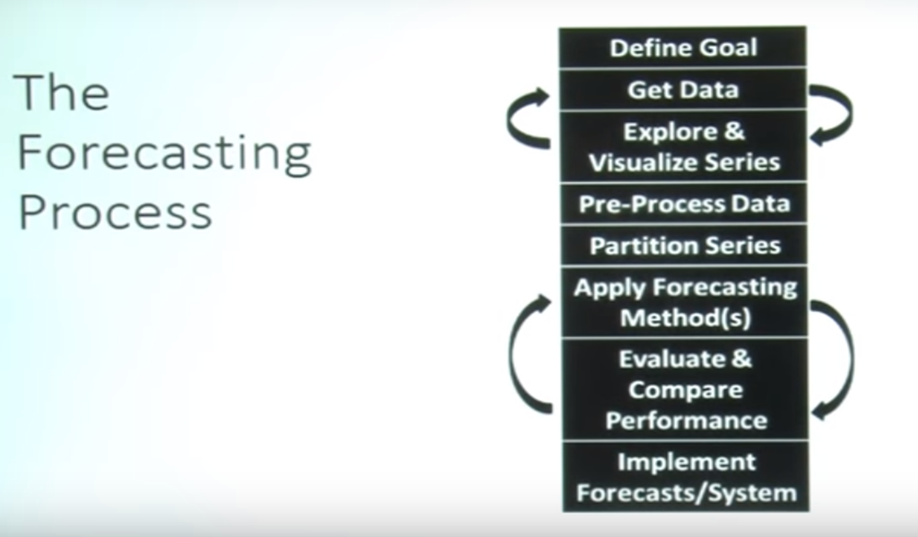

Forecasting Process

Forecasting Process

## Goals

1. Forecast monthly user ridership on its trains for the purpose of Pricing. Using demand data to determine Pricing is called “revenue management” and is a popular practice by airlines and hotel chains. It is a Predictive Goal.
2. Impact Assessment: Evaluating the effect of an event on the timeline such as Airport closure due to inclement weather, or the opening on new large national highway. This goal is retrospective in nature, and is therefore descriptive or even explanatory. Analysis would compare the series before and after the event, with no direct interest in future values of the series. Note that these goals are also geography specific and would therefore require using ridership data at a finer level of geography within United States.
3. Identifying and quantifying Demand during different seasons for planning the number and frequency of trains needed during different seasons. If the model is only aimed at producing monthly indexes of demand, then it is a descriptive goal. In contrast, if the model will be used to forecast seasonal demand for future years then it is a predictive task.
4. Finally, the Amtrack ridership data may be used by national agencies, such as Bureau of Transport Statistics to evaluate trends in transportation modes over the years. Whether it is descriptive or predictive goal depends on what the analysis will be used for. If it is used for the purpose of reporting past trends, then it is descriptive. If the purpose is forecasting future trends, then it is predictive goal.

### Forecast Horizon

Forecast Horizon is the *k* number of periods ahead that we must forecast, and $F_{t+k}$ is a *k*-step-ahead forecast. In Amtrack ridership example, one month ahead forecast $F_{t+1}$ mightbe sufficient for Revenue management for creating flexible pricing. Whereas longer term forecasts, such as three month ahead forecast $F_{t+3}$ are more likely to be needed for scheduling and procurement purpose.

### Forecast Updating

Timeliness of data collection and transfer directly affect the forecast horizon. Whether improving the timeliness of data collection and transfer is possible or not, its implications on forecasting must be recognized at goal definition stage. Refreshing of forecasts based on new data is called *roll-forward forecasting*.

### Forecast Use

Understanding how the forecast will be used, perhaps by different stakeholders, is critical for generating forecasts of the right type and with a useful accuracy level. Should the forecasts be binary(event/non-event)? Does over-production cost more or less than under-production? Will the forecast be used directly or will they be adjusted in some way before use? Will the forecast be presented to management or to the Technical department? Answers to such questions are necessary to choose appropriate data, methods and evaluation schemes.

### Libraries

We will use [Rob J Hyndman’s](https://robjhyndman.com/about/) [forecast](https://www.rdocumentation.org/packages/forecast/versions/8.3) package

```r
require(tidyverse)
require(forecast)
require(xtable)
require(knitr)
require(zoo)
```

Different kinds of Forecasting

### Timeplot

A timeplot of monthly Amtrack ridership is shown in Figure 2.3. Observing the plot reveals nature of time series components.

- Values Scale: Thousands ofriders
- Overall Level: 1,800,000 riders/month
- Trend: Slight U-shaped
- Seasonality: Pronounced, Annual, Peaks: July, August

Figure 2.3: Monthly ridership on AMtrack Trains (in thousands) from Jan 1991 to March 2004

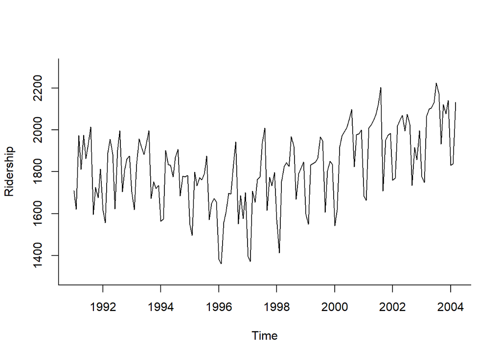

### Trend and Zooming/Window

To fit a quadratic trend, run the forecast package’s linear regression model for time series, called tslm. The y value is ridership and two x values are trend and square of trend. The function I treats square of trend as-is. Plot time series and its fitted regression line in the top panel of figure 2.4 The bottom panel shows a zoomed-in view of timeseries from January 1997 to December 2000. Use the window function to identify a subset of time series.

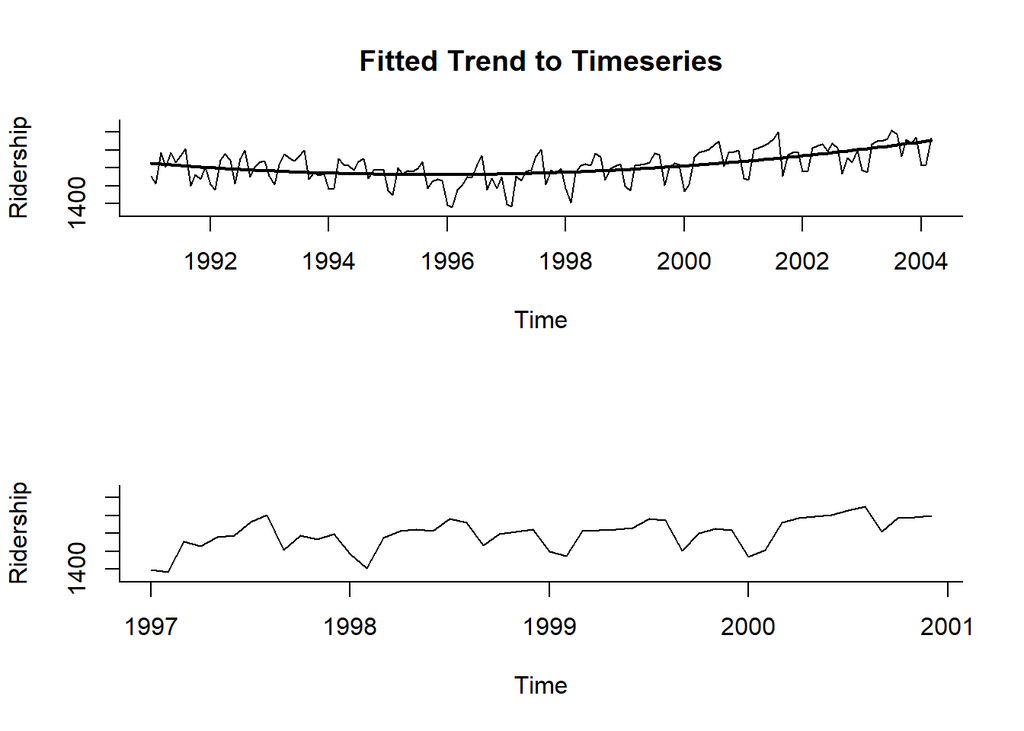

### Partitioning the Data

Temporal partitioning: Partitioning the data in Training and Validation period is a linear process unlike that used in Cross sectional data which must be randomly selected. A random selection on a timeline will cause a “hole”. In the same vein, a third partition - “test”- is not advised as the impact of recency on forecasting is much higher. The latest partition, if made, will affect the forecasting detrimentally. Finally, the last difference is that in Time series, Training and Validation dataset are recombined before attempting to forecast future values.

Define the number of months of training and validation datasets, `nValid` and `nTrain`, respectively. Use the `time` and `window` function to create the training and validation sets. Fit a model (here, a linear regression model) to the training set. Use the `forecast` function to make predictions of time series in the validation period. Plot the predictions.

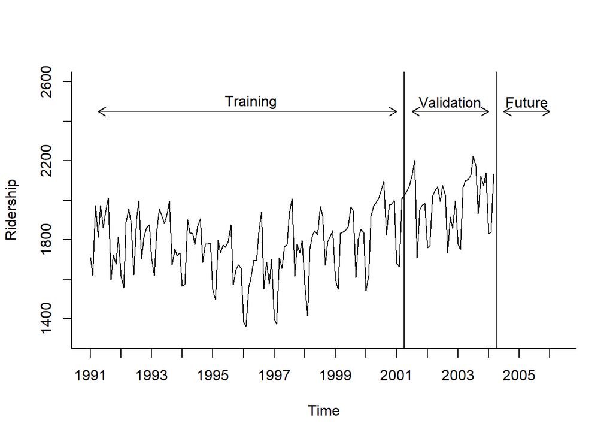

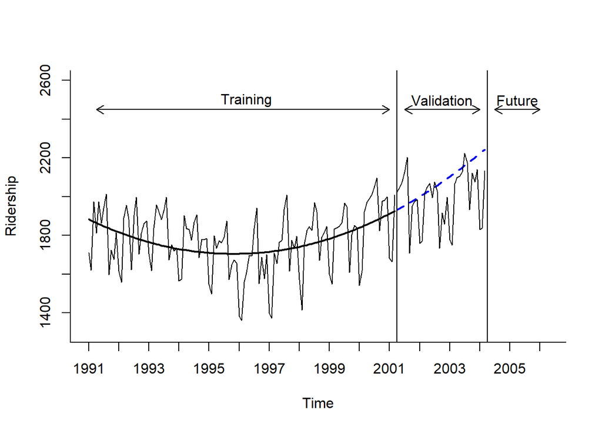

### Computing Predictive Measures

- Forecast Error/ Residual
- MAE/MAD
- Average Error
- MAPE
- RMSE
- Zero Counts affecting MAPE
- MASE
- Forecast accuracy vs Profitability: Balancing the cost and perspective of Type One and Type Two Errors

```
##                 ME     RMSE      MAE       MPE    MAPE      ACF1 Theil's U
## Test set -83.96208 179.8494 133.7383 -4.725374 7.07573 0.4170651  1.062068
```

### Residuals

Use the `names` function to fund out which elements are included with the `forecast` object called `ridership.lm.pred`. The model’s residuals are forecast error in training period. Subtracting the model’s `mean` (or forecasts) from `valid.ts` (or actuals) in the validation period gives the forecast error in the validation period.

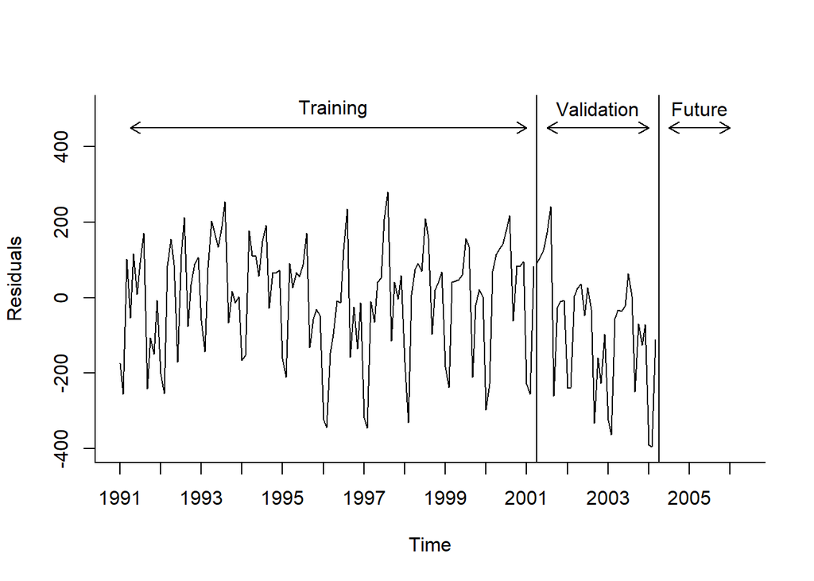

Figure 3.3: Timeplot of forecast errors (residuals) from a quadratic trend model applied to the Amtrack ridership data.

Put the model’s residuals into the `hist` function to plot the histogram of, or frequency of forecast errors in each of seven (automatically and equally sized) bins.

[output not shown]

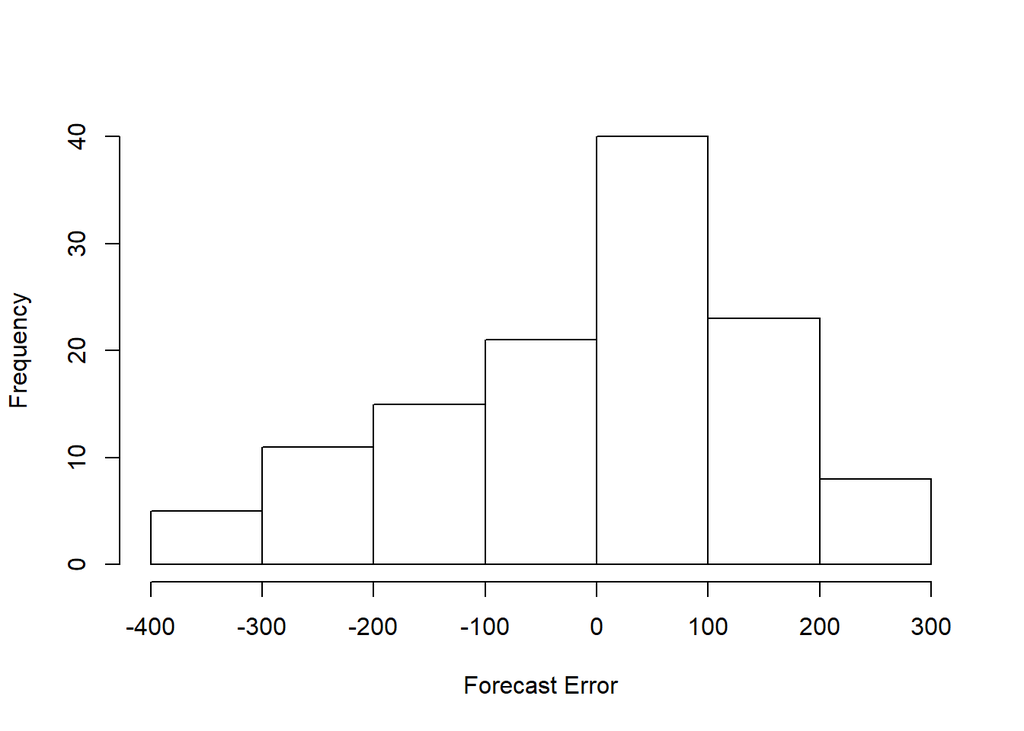

Figure 3.4: Histogram of forecast errors in the Training period from a quadratic trend model applied to the Amtrack ridership data.

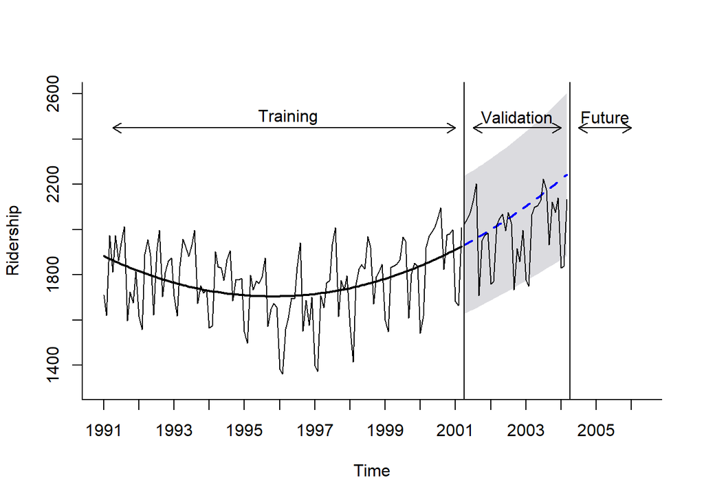

Figure 3.5: Point forecasts and 95% prediction intervals in the validation period gained from a quadratic trend model applied to the Amtrack ridership data. (`level = 95`)

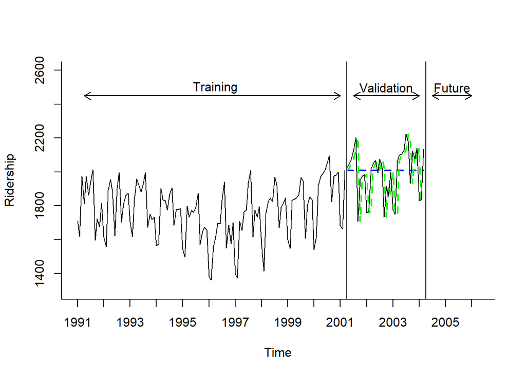

Figure 3.7: Naïve forecasts using a fixed validation period (Dashed horizontal line in blue) vs one-step-ahead Naïve forecasts using monthly roll-forward validation period (other dashed line in green) for Amtrack ridership data. The actual values are plotted with a smooth line.

```
## [1] 119.4289
```

```
## [1] 169.1733
```

```
## [1] 0.06206066
```

```
##                     ME     RMSE      MAE        MPE     MAPE     MASE
## Training set   2.45091 168.1470 125.2975 -0.3460027 7.271393 1.518906
## Test set     -14.71772 142.7551 115.9234 -1.2749992 6.021396 1.405269
##                    ACF1 Theil's U
## Training set -0.2472621        NA
## Test set      0.2764480 0.8346967
```

```
##                    ME     RMSE      MAE       MPE     MAPE     MASE
## Training set 13.93991 99.26557 82.49196 0.5850656 4.715251 1.000000
## Test set     54.72961 95.62433 84.09406 2.6527928 4.247656 1.019421
##                   ACF1 Theil's U
## Training set 0.6400044        NA
## Test set     0.6373346 0.5532435
```

|  | Actual | Naive | Seasonal.Naive |
| --- | --- | --- | --- |
| 2001 Apr | 2023.792 | 2007.928 | 1971.493 |
| 2001 May | 2047.008 | 2007.928 | 1992.301 |
| 2001 Jun | 2072.913 | 2007.928 | 2009.763 |
| 2001 Jul | 2126.717 | 2007.928 | 2053.996 |
| 2001 Aug | 2202.638 | 2007.928 | 2097.471 |
| 2001 Sep | 1707.693 | 2007.928 | 1823.706 |
| 2001 Oct | 1950.716 | 2007.928 | 1976.997 |
| 2001 Nov | 1973.614 | 2007.928 | 1981.408 |
| 2001 Dec | 1984.729 | 2007.928 | 2000.153 |
| 2002 Jan | 1759.629 | 2007.928 | 1683.148 |

[output cut: 26 more lines]

```
##            Actual    Naive Seasonal Naive
## Apr 2001 2023.792 2007.928       1971.493
## May 2001 2047.008 2007.928       1992.301
## Jun 2001 2072.913 2007.928       2009.763
## Jul 2001 2126.717 2007.928       2053.996
## Aug 2001 2202.638 2007.928       2097.471
## Sep 2001 1707.693 2007.928       1823.706
```

Comparison of Accuracy Metrics

[output not shown]

Table 3.5: Performance of naïve vs seasonal naïve forecasts using fixed partitioning

# Smoothening

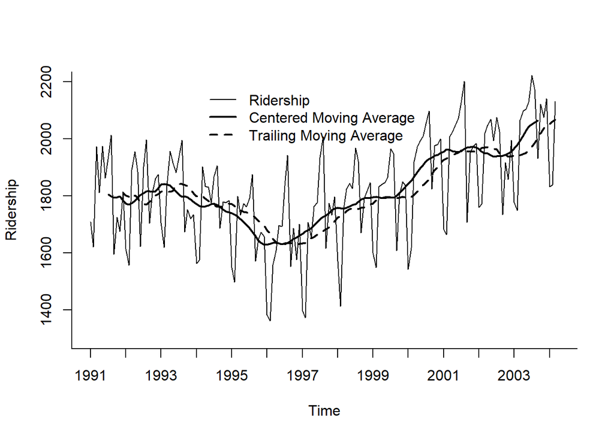

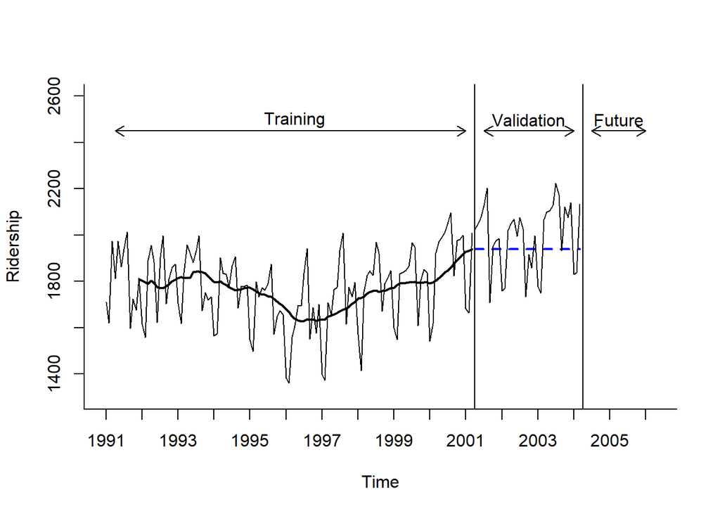

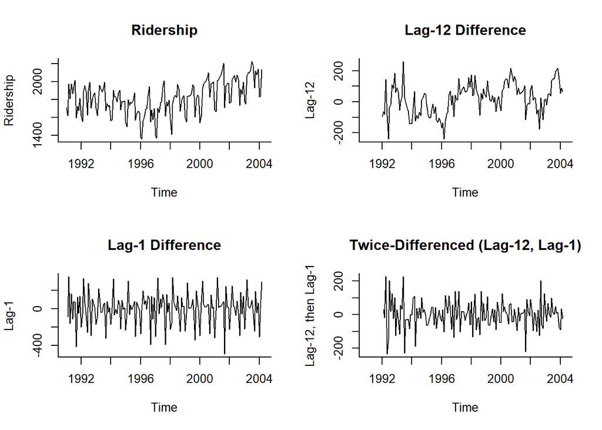

```
##
## Call:
## tslm(formula = ridership.deseasonalized ~ trend)
##
## Residuals:
##      Min       1Q   Median       3Q      Max
## -241.873  -56.022   -0.219   59.150  284.792
##
## Coefficients:
##             Estimate Std. Error t value Pr(>|t|)
## (Intercept) -40.3641    15.0455  -2.683  0.00815 **
## trend         0.8294     0.1764   4.702 5.93e-06 ***
## ---
## Signif. codes:  0 '***' 0.001 '**' 0.01 '*' 0.05 '.' 0.1 ' ' 1
##
## Residual standard error: 90.74 on 145 degrees of freedom
## Multiple R-squared:  0.1323, Adjusted R-squared:  0.1263
## F-statistic: 22.11 on 1 and 145 DF,  p-value: 5.935e-06
```

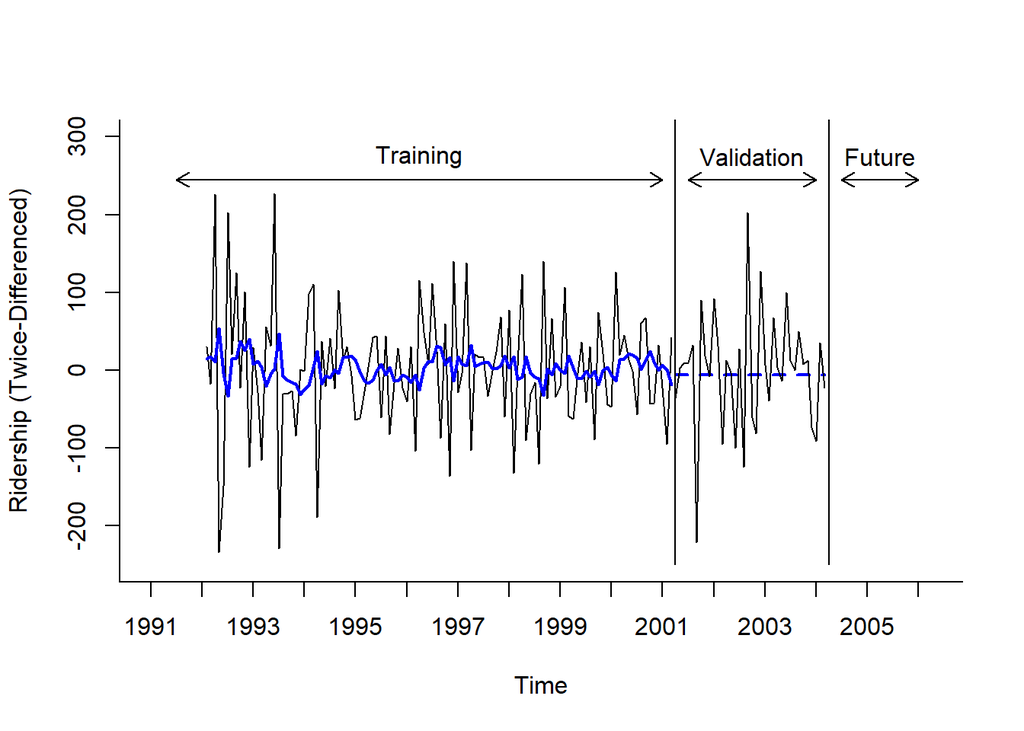

```
## ETS(A,N,N)
##
## Call:
##  ets(y = train.ts, model = "ANN")
##
##   Smoothing parameters:
##     alpha = 1e-04
##
##   Initial states:
##     l = 1.4679
##
##   sigma:  83.5845
##
##      AIC     AICc      BIC
## 1494.723 1494.950 1502.825
```

```
##                      ME     RMSE      MAE       MPE     MAPE      MASE
## Training set -0.9407425 90.82254 68.01782 181.35457 225.2854 0.6669040
## Test set      5.7226043 75.99033 54.88964  55.92139 178.3106 0.5381843
##                    ACF1 Theil's U
## Training set -0.3678952        NA
## Test set     -0.3665235     1.113
```

```
##                      ME     RMSE      MAE      MPE     MAPE      MASE
## Training set  0.1883115 82.82115 62.90072 100.5062 105.4250 0.6167316
## Test set     -2.0924502 75.80343 53.05667 110.2116 110.2116 0.5202123
##                    ACF1 Theil's U
## Training set -0.3398587        NA
## Test set     -0.3665235 0.9662741
```

```
## Series: train.ts
## ARIMA(1,0,1)(0,0,1)[12] with non-zero mean
##
## Coefficients:
##          ar1      ma1     sma1    mean
##       0.3850  -0.8181  -0.7545  1.3775
## s.e.  0.1529   0.1032   0.1100  0.7093
##
## sigma^2 estimated as 3894:  log likelihood=-614.1
## AIC=1238.2   AICc=1238.78   BIC=1251.7
```

```
## ETS(M,N,A)
##
## Call:
##  ets(y = rts)
##
##   Smoothing parameters:
##     alpha = 0.5157
##     gamma = 8e-04
##
##   Initial states:
##     l = 1813.5087
##     s=28.527 -16.1115 -3.9429 -121.4959 203.2382 154.7662
##            30.7515 74.6798 50.5657 44.6936 -250.4517 -195.2199
##
##   sigma:  0.0352
##
##      AIC     AICc      BIC
## 1437.993 1443.100 1478.500
```

```
##  [1]  56.89533  72.41222  47.58071 109.40784 105.01269  70.84465  64.63404
##  [8]  65.44567  80.81070 134.14835 132.05848 103.71279 106.18907 107.98966
## [15] 109.53008 110.97033 112.37201 113.75885 115.13997 116.51889 117.89696
## [22] 119.27470 120.65232 122.02989 123.40744 124.78498 126.16252 127.54006
## [29] 128.91760 130.29514 131.67268 133.05022 134.42776 135.80530 137.18284
## [36] 138.56038
```

```
##  [1] 1971.493 1992.301 2009.763 2053.996 2097.471 1823.706 1976.997
##  [8] 1981.408 2000.153 1683.148 1663.404 2007.928 2028.388 2064.713
## [15] 2057.344 2163.404 2202.484 1894.551 2041.631 2046.854 2080.964
## [22] 1817.296 1795.462 2111.641 2134.577 2172.703 2166.874 2274.374
## [29] 2314.856 2008.310 2156.771 2163.373 2198.861 1936.571 1916.115
## [36] 2233.671 2257.985 2297.488 2293.036 2401.914 2443.773 2138.605
## [43] 2288.444 2296.423 2333.288 2072.376 2053.298 2372.231
```

```
##  [1] 2028.388 2064.713 2057.344 2163.404 2202.484 1894.551 2041.631
##  [8] 2046.854 2080.964 1817.296 1795.462 2111.641 2134.577 2172.703
## [15] 2166.874 2274.374 2314.856 2008.310 2156.771 2163.373 2198.861
## [22] 1936.571 1916.115 2233.671 2257.985 2297.488 2293.036 2401.914
## [29] 2443.773 2138.605 2288.444 2296.423 2333.288 2072.376 2053.298
## [36] 2372.231
```

```
##                 ME     RMSE     MAE       MPE    MAPE
## Test set -152.0855 174.9945 152.959 -7.714254 7.75637
```

[output not shown]

[output cut: 428 more lines]

[output not shown]

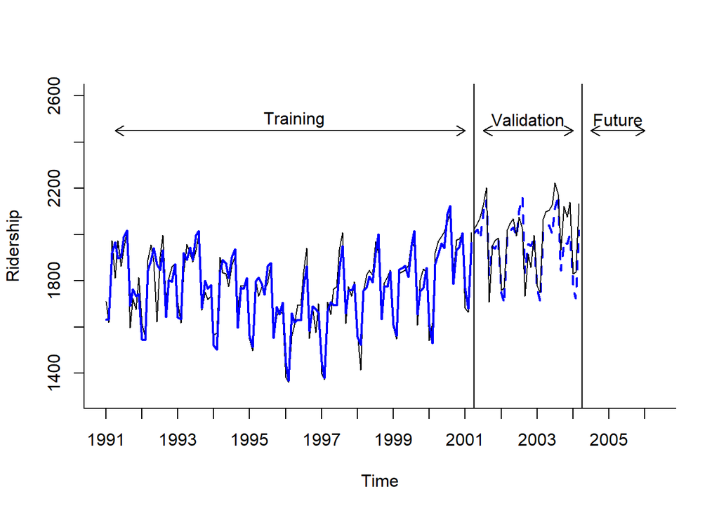

```
## ETS(M,A,A)
##
## Call:
##  ets(y = train.ts, model = "MAA")
##
##   Smoothing parameters:
##     alpha = 0.5518
##     beta  = 1e-04
##     gamma = 1e-04
##
##   Initial states:
##     l = 1838.577
##     b = 0.8081
##     s=28.4454 -11.2187 -0.5337 -124.2766 200.1969 146.8103
##            36.5908 76.044 60.153 44.1791 -249.4682 -206.9221
##
##   sigma:  0.0342
##
##      AIC     AICc      BIC
## 1617.596 1623.424 1665.403
```

```
##            l            b           s1           s2           s3
## 1838.5770301    0.8081064   28.4453626  -11.2186753   -0.5336870
##           s4           s5           s6           s7           s8
## -124.2766167  200.1968557  146.8102880   36.5907511   76.0439635
##           s9          s10          s11          s12
##   60.1530346   44.1790580 -249.4681974 -206.9221371
```

```
##            l            b           s1           s2           s3
## 1944.5564806    0.8100101   44.1899049 -249.4709519 -206.9249239
##           s4           s5           s6           s7           s8
##   28.4436406  -11.2161757   -0.5324645 -124.2747514  200.1936173
##           s9          s10          s11          s12
##  146.8106008   36.5892133   76.0565944   60.1377124
```

[output not shown]

[output cut: 320 more lines]

[output not shown]

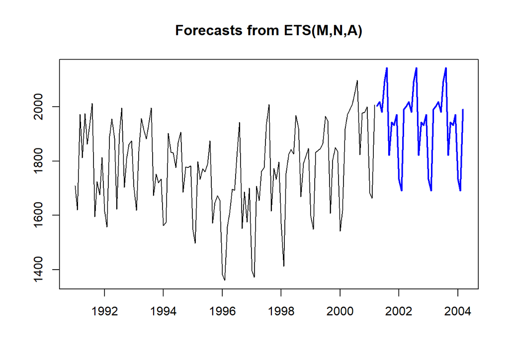

```
##                      ME     RMSE      MAE         MPE     MAPE      MASE
## Training set  0.1382018 56.49150 45.22527 -0.07920944 2.579613 0.5482385
## Test set     33.6684422 76.65107 62.16977  1.58152634 3.122042 0.7536464
##                    ACF1 Theil's U
## Training set 0.06063493        NA
## Test set     0.61655528 0.4430438
```

```
##                    ME     RMSE      MAE        MPE     MAPE      MASE
## Training set  1.98570 56.86248 45.21332 0.02883941 2.576978 0.5480937
## Test set     49.72735 88.62810 73.96379 2.39118826 3.707185 0.8966182
##                    ACF1 Theil's U
## Training set 0.06113138        NA
## Test set     0.65425349 0.5135193
```

# Smoothening

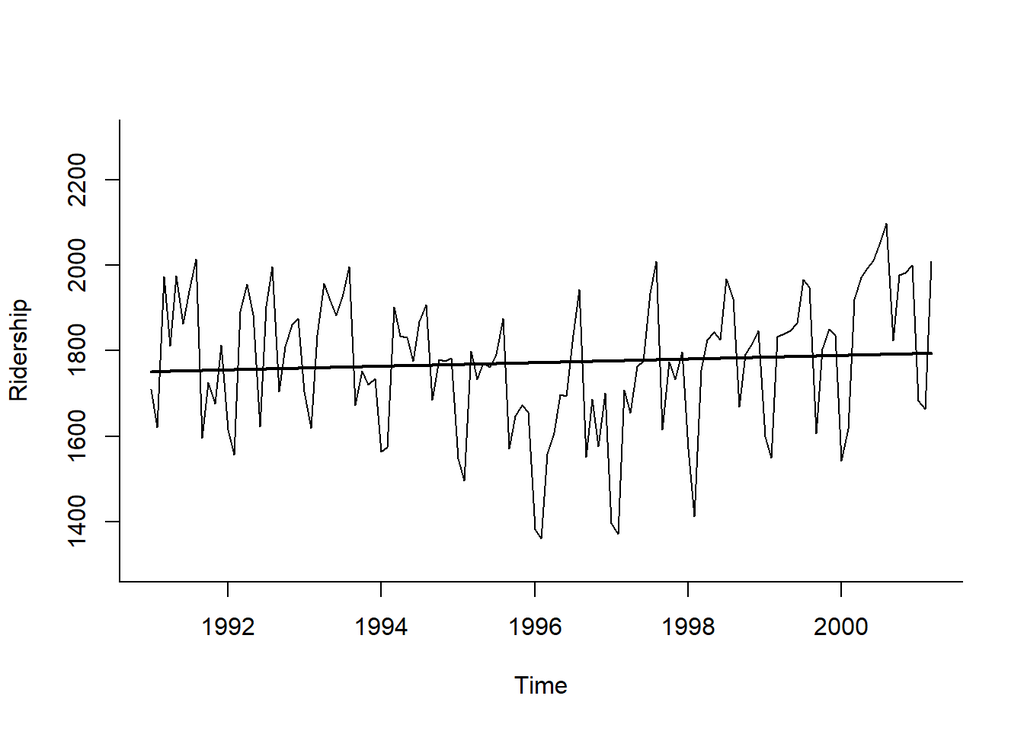

```
##
## Call:
## tslm(formula = train.ts ~ trend)
##
## Residuals:
##     Min      1Q  Median      3Q     Max
## -411.29 -114.02   16.06  129.28  306.35
##
## Coefficients:
##              Estimate Std. Error t value Pr(>|t|)
## (Intercept) 1750.3595    29.0729  60.206   <2e-16 ***
## trend          0.3514     0.4069   0.864     0.39
## ---
## Signif. codes:  0 '***' 0.001 '**' 0.01 '*' 0.05 '.' 0.1 ' ' 1
##
## Residual standard error: 160.2 on 121 degrees of freedom
## Multiple R-squared:  0.006125,   Adjusted R-squared:  -0.002089
## F-statistic: 0.7456 on 1 and 121 DF,  p-value: 0.3896
```

## Box-Cox Transformation

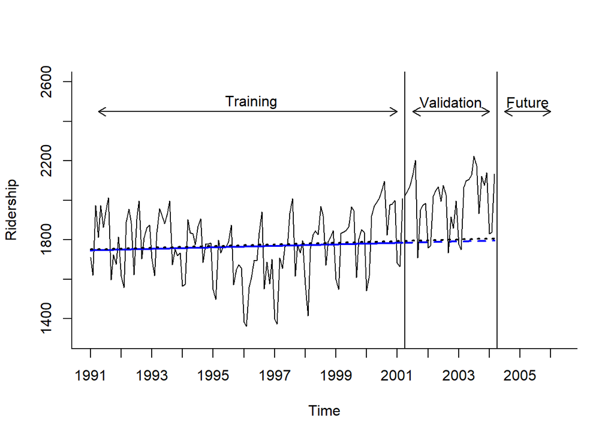

```
##           Jan      Feb      Mar      Apr      May      Jun      Jul
## 1991 7.443615 7.390543 7.587166 7.502002 7.588305 7.529598 7.570371
## 1992 7.386983 7.350573 7.544979 7.578647 7.541531 7.392057 7.551349
## 1993 7.441472 7.389277 7.515731 7.579190 7.558613 7.540302 7.566833
## 1994 7.354596 7.361349 7.550997 7.514194 7.512644 7.481981 7.532360
## 1995 7.344987 7.311168 7.494606 7.457549 7.480059 7.473755 7.490895
## 1996 7.231112 7.215866 7.351527 7.383008 7.436438 7.434365 7.515081
## 1997 7.241787 7.223799 7.442798 7.411317 7.474717 7.482006 7.567459
## 1998 7.359041 7.253252 7.470020 7.509298 7.519307 7.509863 7.584860
## 1999 7.377401 7.345238 7.513345 7.517369 7.521046 7.530937 7.583626
## 2000 7.340615 7.388283 7.559840 7.586546 7.597046 7.605772 7.627542
## 2001 7.428421 7.416621 7.604859
##           Aug      Sep      Oct      Nov      Dec
## 1991 7.607513 7.375041 7.452938 7.423967 7.503214
## 1992 7.599257 7.440673 7.501082 7.529192 7.536429
## 1993 7.598984 7.422279 7.468985 7.450299 7.458355
## 1994 7.553081 7.429896 7.483551 7.482116 7.486249
## 1995 7.536268 7.359664 7.406679 7.422153 7.412670
## 1996 7.571769 7.346914 7.430415 7.362775 7.438638
## 1997 7.604922 7.387662 7.480941 7.457245 7.493666
## 1998 7.560937 7.420338 7.490794 7.504785 7.521185
## 1999 7.575073 7.382356 7.497575 7.523108 7.515581
## 2000 7.648488 7.508626 7.589334 7.591563 7.600979
## 2001
```

## Smoothening with various Permuations of Interaction Terms

```
##
## Call:
## tslm(formula = train.ts ~ trend + I(trend^2))
##
## Residuals:
##     Min      1Q  Median      3Q     Max
## -344.79 -101.86   40.89   98.54  279.81
##
## Coefficients:
##               Estimate Std. Error t value Pr(>|t|)
## (Intercept) 1888.88401   40.91521  46.166  < 2e-16 ***
## trend         -6.29780    1.52327  -4.134 6.63e-05 ***
## I(trend^2)     0.05362    0.01190   4.506 1.55e-05 ***
## ---
## Signif. codes:  0 '***' 0.001 '**' 0.01 '*' 0.05 '.' 0.1 ' ' 1
##
## Residual standard error: 148.8 on 120 degrees of freedom
## Multiple R-squared:  0.1499, Adjusted R-squared:  0.1358
## F-statistic: 10.58 on 2 and 120 DF,  p-value: 5.844e-05
```

```
##
## Call:
## tslm(formula = train.ts ~ season)
##
## Residuals:
##      Min       1Q   Median       3Q      Max
## -276.165  -52.934    5.868   54.544  215.081
##
## Coefficients:
##             Estimate Std. Error t value Pr(>|t|)
## (Intercept)  1573.97      30.58  51.475  < 2e-16 ***
## season2       -42.93      43.24  -0.993   0.3230
## season3       260.77      43.24   6.030 2.19e-08 ***
## season4       245.09      44.31   5.531 2.14e-07 ***
## season5       278.22      44.31   6.279 6.81e-09 ***
## season6       233.46      44.31   5.269 6.82e-07 ***
## season7       345.33      44.31   7.793 3.79e-12 ***
## season8       396.66      44.31   8.952 9.19e-15 ***
## season9        75.76      44.31   1.710   0.0901 .
## season10      200.61      44.31   4.527 1.51e-05 ***
## season11      192.36      44.31   4.341 3.14e-05 ***
## season12      230.42      44.31   5.200 9.18e-07 ***
## ---
## Signif. codes:  0 '***' 0.001 '**' 0.01 '*' 0.05 '.' 0.1 ' ' 1
##
## Residual standard error: 101.4 on 111 degrees of freedom
## Multiple R-squared:  0.6348, Adjusted R-squared:  0.5986
## F-statistic: 17.54 on 11 and 111 DF,  p-value: < 2.2e-16
```

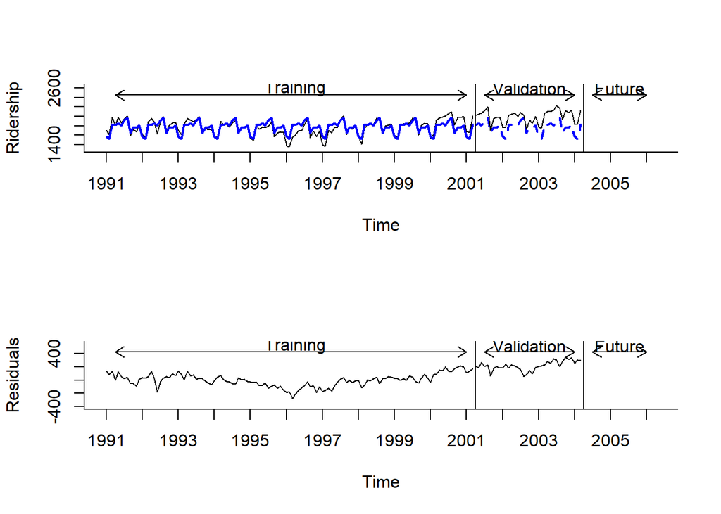

```
##
## Call:
## tslm(formula = train.ts ~ trend + I(sin(2 * pi * trend/12)) +
##     I(cos(2 * pi * trend/12)))
##
## Residuals:
##     Min      1Q  Median      3Q     Max
## -318.34  -96.30    8.04   89.73  307.89
##
## Coefficients:
##                            Estimate Std. Error t value Pr(>|t|)
## (Intercept)               1748.0335    25.0477  69.788  < 2e-16 ***
## trend                        0.4229     0.3507   1.206  0.23015
## I(sin(2 * pi * trend/12))  -48.2666    17.5260  -2.754  0.00681 **
## I(cos(2 * pi * trend/12)) -106.5245    17.6773  -6.026 1.93e-08 ***
## ---
## Signif. codes:  0 '***' 0.001 '**' 0.01 '*' 0.05 '.' 0.1 ' ' 1
##
## Residual standard error: 137.9 on 119 degrees of freedom
## Multiple R-squared:  0.2762, Adjusted R-squared:  0.2579
## F-statistic: 15.14 on 3 and 119 DF,  p-value: 2.088e-08
```

[figure not shown]

```
##
## Call:
## tslm(formula = train.ts ~ trend + I(trend^2) + season)
##
## Residuals:
##      Min       1Q   Median       3Q      Max
## -213.775  -39.363    9.711   42.422  152.187
##
## Coefficients:
##               Estimate Std. Error t value Pr(>|t|)
## (Intercept)  1.697e+03  2.768e+01  61.318  < 2e-16 ***
## trend       -7.156e+00  7.293e-01  -9.812  < 2e-16 ***
## I(trend^2)   6.074e-02  5.698e-03  10.660  < 2e-16 ***
## season2     -4.325e+01  3.024e+01  -1.430  0.15556
## season3      2.600e+02  3.024e+01   8.598 6.60e-14 ***
## season4      2.606e+02  3.102e+01   8.401 1.83e-13 ***
## season5      2.938e+02  3.102e+01   9.471 6.89e-16 ***
## season6      2.490e+02  3.102e+01   8.026 1.26e-12 ***
## season7      3.606e+02  3.102e+01  11.626  < 2e-16 ***
## season8      4.117e+02  3.102e+01  13.270  < 2e-16 ***
## season9      9.032e+01  3.102e+01   2.911  0.00437 **
## season10     2.146e+02  3.102e+01   6.917 3.29e-10 ***
## season11     2.057e+02  3.103e+01   6.629 1.34e-09 ***
## season12     2.429e+02  3.103e+01   7.829 3.44e-12 ***
## ---
## Signif. codes:  0 '***' 0.001 '**' 0.01 '*' 0.05 '.' 0.1 ' ' 1
##
## Residual standard error: 70.92 on 109 degrees of freedom
## Multiple R-squared:  0.8246, Adjusted R-squared:  0.8037
## F-statistic: 39.42 on 13 and 109 DF,  p-value: < 2.2e-16
```

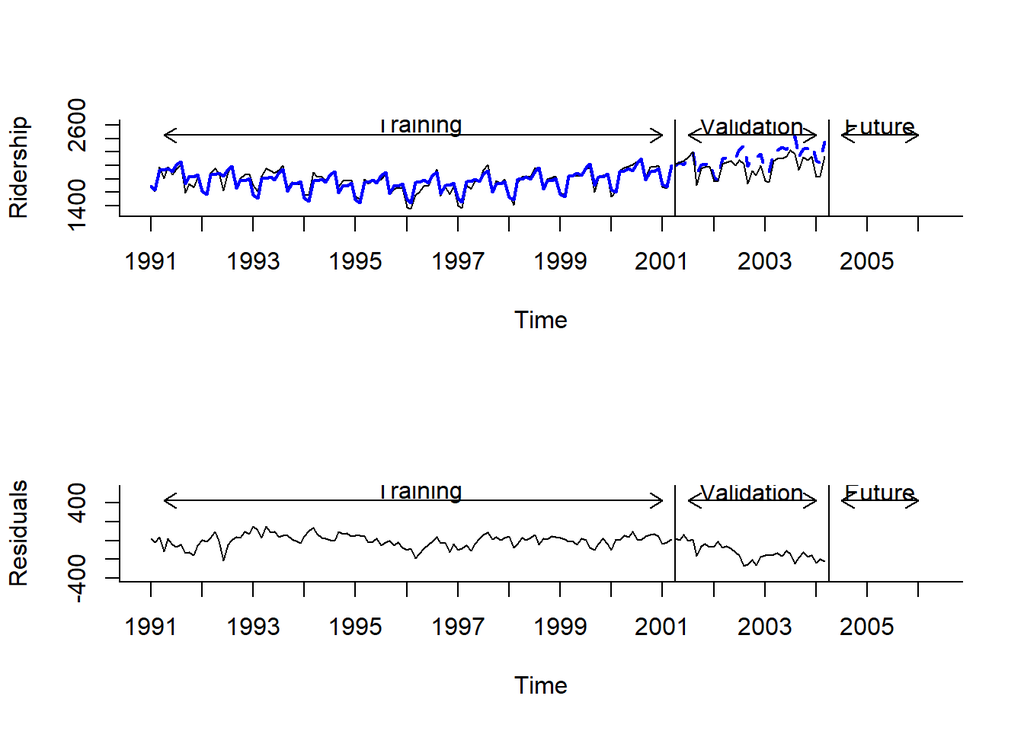

# Auto Correlations Plot and Treatment

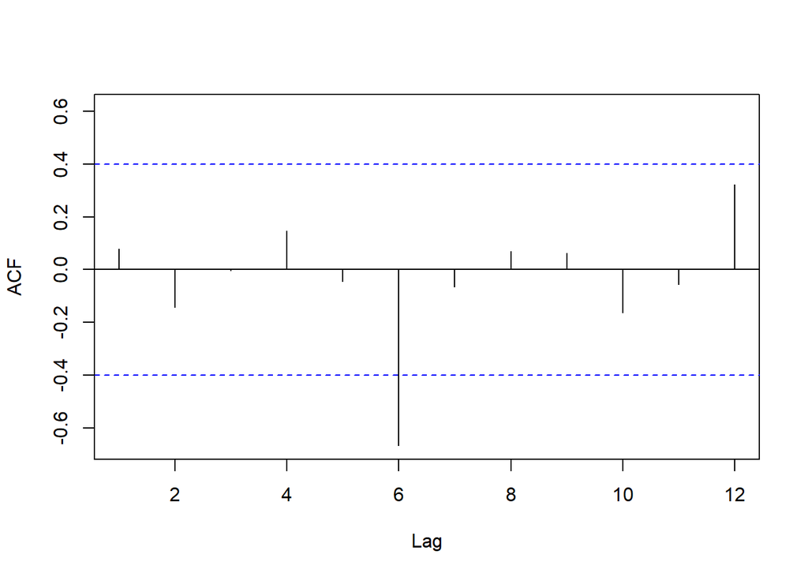

### Accounitng for Seasonality and Autocorrelation

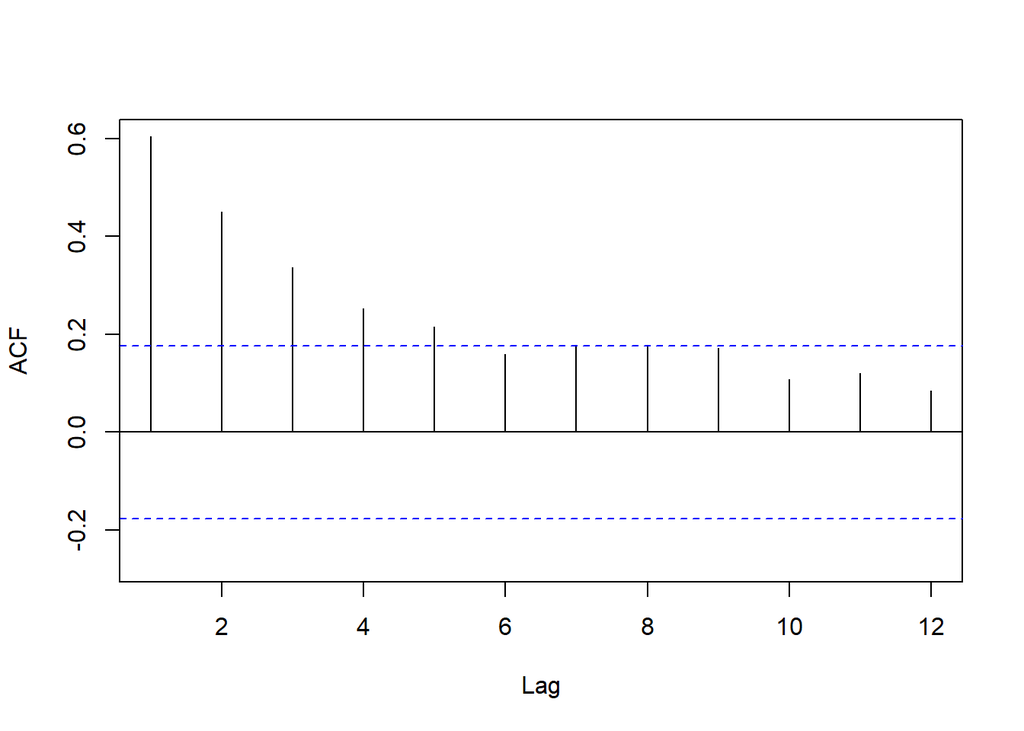

```
## , , 1
##
##             [,1]
##  [1,] 1.00000000
##  [2,] 0.60405883
##  [3,] 0.44983171
##  [4,] 0.33730830
##  [5,] 0.25329034
##  [6,] 0.21565844
##  [7,] 0.15901326
##  [8,] 0.17676683
##  [9,] 0.17553762
## [10,] 0.17140882
## [11,] 0.10739472
## [12,] 0.11976519
## [13,] 0.08512942
```

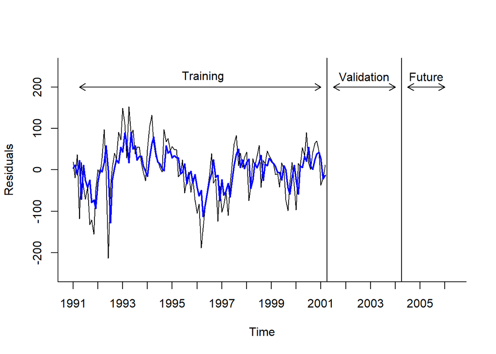

```
## Series: train.lm.trend.season$residuals
## ARIMA(1,0,0) with non-zero mean
##
## Coefficients:
##          ar1     mean
##       0.5998   0.3728
## s.e.  0.0712  11.8408
##
## sigma^2 estimated as 2876:  log likelihood=-663.54
## AIC=1333.08   AICc=1333.29   BIC=1341.52
##
## Training set error measures:
##                      ME     RMSE     MAE      MPE     MAPE      MASE
## Training set -0.1223159 53.19141 39.8277 103.3885 175.2219 0.5721356
##                     ACF1
## Training set -0.07509305
```

### Fitting Neural Nets to forecasting

```
## [1] 159
```

[output not shown]

```
##                      ME      RMSE       MAE         MPE      MAPE
## Training set  0.1345029   4.60624  3.355614 0.001476058 0.1921153
## Test set     87.7655536 121.60742 97.251127 4.250144613 4.7525810
##                    MASE        ACF1 Theil's U
## Training set 0.04067807 -0.03689506        NA
## Test set     1.17891637  0.62628789 0.6955393
```

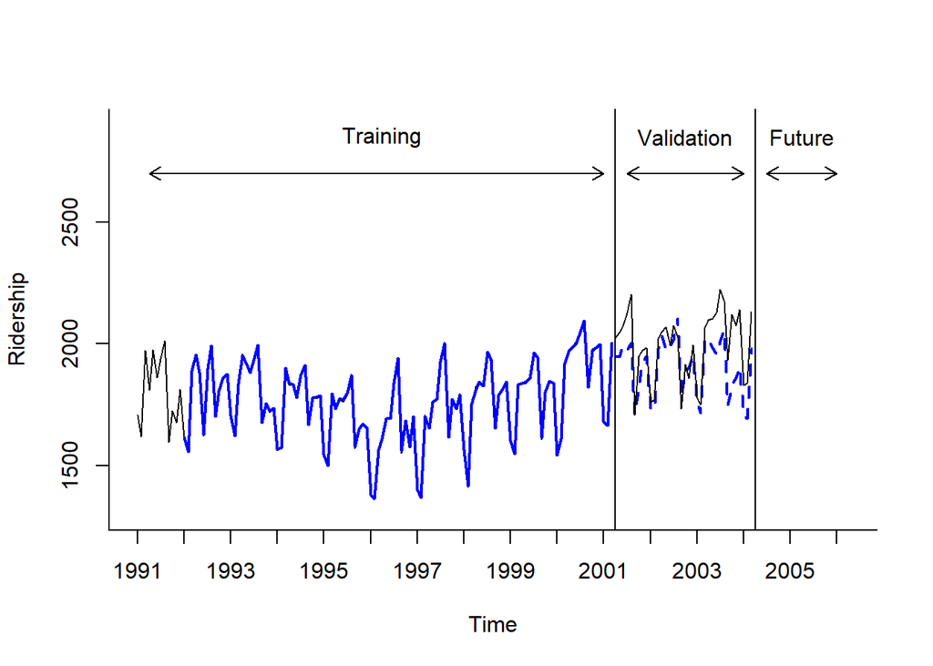

```
## Series: train.ts
## Model:  NNAR(2,1,2)[12]
## Call:   nnetar(y = train.ts)
##
## Average of 20 networks, each of which is
## a 3-2-1 network with 11 weights
## options were - linear output units
##
## sigma^2 estimated as 6766
```

```
##                       ME      RMSE       MAE        MPE     MAPE      MASE
## Training set  -0.3492673  82.25378  67.07129 -0.2610314 3.875977 0.8130646
## Test set     -37.1540134 130.87578 100.48248 -2.2095656 5.236845 1.2180881
##                   ACF1 Theil's U
## Training set 0.3979050        NA
## Test set     0.3529398  0.762112
```